# UB10 – Tutorium Mathe A WS19/20

A. Hanke

Tutorium: 19/12/2019

# Aufgabe 1

Wollen Grenzwerte der Folgen bestimmen:
$$\begin{array}{l}{\text { (1) } a_{n}=\frac{n^{2}}{(n+1)(n+2)} ; \quad(2) a_{n}=\frac{n^{2}}{n+1}-\frac{n^{3}}{(n+1)(n+2)} ; \quad(3) a_{n}=n-5-\frac{n^{3}}{n^{2}+5}} \\ {\qquad(4) a_{n}=\cos n \pi ; \quad(5) a_{n}=\cos n(n+1) \pi}\end{array}$$

### (1)

$$a_n = \frac{n^2}{n^2 + 3n + 2} = \frac{n^2}{n^2(1+\frac{3n}{n^2}+\frac{2}{n^2}} = \frac{1}{1+\frac{3}{n}+\frac{2}{n^2}} \quad \lim_{n \rightarrow \infty} a_n = 1$$

### (2)

$\lim_{n \rightarrow \infty} = 2$

### (3)

$\lim_{n \rightarrow \infty} = -5$

### (4)

$a_{n}=\cos n \pi$ hat folgende Werte zu begin:

- $a_0 = 1$
- $a_1 = -1$
- $a_2 = 1$

Entspricht der Folge: $(-1)^n$. Diese Konvergiert nicht.

### (5)

Hier von interesse ist die enthaltene Reihe:
$$a'_n = n(n+1)$$
Diese Reihe beinhaltet nur gerade Zahlen. Daher ist die Folge $a_n$:
$$a_n = \cos(n(n+1)\pi) = 1 \qquad \forall n$$

# Aufgabe 2

$$a_{n+1}=\frac{\left|a_{n}\right|}{2 a_{n}-1}
\qquad a_1 = b \quad b = \left\{-\frac{1}{4},\: \frac{1}{4}\right\}$$

### (a)

Annahme: $a_n \rightarrow a$
Bedingung an $a$ nach rekursionsformel:
$$\lim_{n \rightarrow \infty} \frac{\left|a_{n}\right|}{2 a_{n}-1} =
\frac{\left|a\right|}{2 a-1}$$
Nun gilt das $a_n$ gegen $a$ läuft, also: $\lim a_n = a$.
$$a = \frac{|a|}{2a-1} \Leftrightarrow
\left\{\begin{array}{c}
2a^2-a = |a|\\
2a^2-a - |a| = 0\\
\end{array}\right.$$
Nun können wir zwei Fälle betrachten:

1. Die Folge strebt einen Positiven Wert an $a > 0:\quad a = |a|$
   $$\left.
   \begin{array}{rl}
   0 &= 2a^2 - 2a\\
   &= a(a-1)\\
   \end{array}
   \right\}\, a = \{1\}$$
2. Die Folge strebt einen negativen Wert an $a \leq 0:\quad a = -|a| \Leftrightarrow -a = |a|$
   $$\left.
   \begin{array}{rl}
   0 &= 2a^2 - a - (-a)\\
   &= 2a^2\\
   \end{array}
   \right\}\, a = \{0\}$$

### (b)

Wir Berechnen der ersten drei weiteren $a_n$:

```
## n = 1 -> -0.25
```

```
## n = 2 -> -0.166666666666667
```

```
## n = 3 -> -0.125
```

```
## n = 4 -> -0.1
```

Die obere Beschränktheit zeigen wir nun über die Definition dieser $\forall n \in \mathbb{N}:\, a_n \leq a$.  
Also zeigen, dass $a_n < 0$

- $a_1 <0$
- Annahme: $a_n < 0$
  $$a_{n+1} = \frac{|a_n|}{2a_n-1} = \frac{\overbrace{-a_n}^{>0} }{\underbrace{2a_n-1}_{<0}} < 0.$$

Nun zeigen, dass Folge monoton steigt. Dies ist der Fall, wenn $a_{n+1} - a_n > 0$
$$\begin{aligned}
a_{n+1} - a_n &= \frac{-a_n}{2a_n -1} -a_n\\
&= \frac{-a_n - 2a_n^2 +a_n}{2a_n-1}\\
&= \frac{\overbrace{-2a_n^2}^{<0}}{\underbrace{2a_n-1}_{<0}}\\
&>0
\end{aligned}$$

### (c)

Wir beachten den Hinweis:

```
## n = 1 -> 0.25
```

```
## n = 2 -> -0.5
```

```
## n = 3 -> -0.25
```

```
## n = 4 -> -0.166666666666667
```

# Konvergenz nicht gleich Monotonie und/oder Beschränktheit!

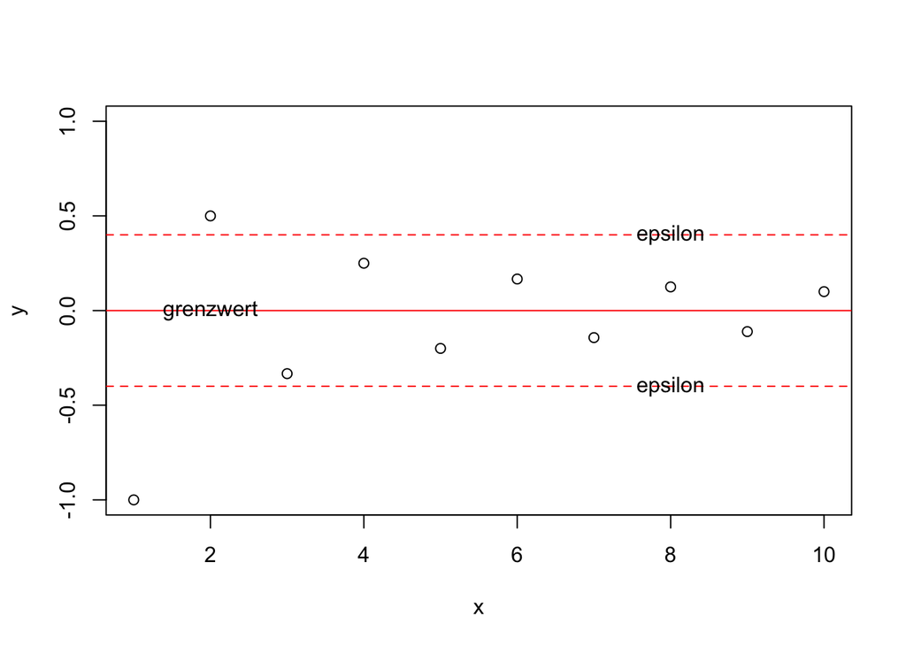

### (d)

Für $a=-\frac{1}{4}$ konvergiert die Folge (oben beschränkt und monoton steigend). Aus (a) Fall 2 wissen wir, das diese Reihe den Grenzwert 0 hat. Da die Reihe für beide $b$ gleiches verhalten zeigt gilt dies auch für das andere b.

# Aufgabe 3

### (a)

Mit $c=-2$ ergeben sich folgende Werte für die ersten Therme der Folge $a_{n+1}=\frac{n^2\cdot a_n^2+c}{n+1}$:

$$a_1=\frac{0^2\cdot0^2-2}{0+1}=-2$$

$$a_2=\frac{1^2\cdot (-2)^2-2}{1+1}=\frac{2}{2} = 1$$

$$a_3=\frac{2^2\cdot 1^2-2}{2+1}=\frac{2}{3}$$

$$a_4=\frac{3^2\cdot (\frac{2}{3})^2-2}{3+1}=\frac{2}{4}$$

$$a_5=\frac{4^2\cdot (\frac{2}{4})^2-2}{4+1}=\frac{2}{5}$$

Dies lässt vermuten, dass es sich für $c=-2$ bei dieser Folge um eine explizite Folge handelt mit der Form: $a_n=\frac{2}{n} \quad \text{für} \quad n\geq2$

Dies wollen wir nun durch vollständige Induktion beweisen:

**Induktionsanfang:**  
$n= 2 \quad \Rightarrow \quad a_2=\frac{2}{2}$

**Induktionsannahme:**  
$a_n = \frac{2}{n} \quad \text{gilt für alle} \quad n\in\mathbb{N}$

**Induktionsbehauptung:**  
$a_{n+1}=\frac{2}{n+1}$

**Induktionsschritt:**  
$a_{n+1}= \frac{n^2\cdot a_n^2-2}{n+1}=\frac{n^2\cdot (\frac{2}{n})^2-2}{n+1}=\frac{4-2}{n+1}=\frac{2}{n+1} \quad \text{q.e.d.}$

### (b)

Die Reihe konvergiert gegen einen Wert $a$, da: $\forall \epsilon > 0, \exists n_0 : \forall n \geq n_0 |a_n| \leq \epsilon$

Grenzwertbestimmung:  
$\lim_{n \rightarrow \infty}a_n=\lim_{n \rightarrow \infty}\frac{2}{n}=0$

Somit konvergiert die Folge gegen Null, d.h. $a_n$ ist eine Nullfolge und somit gilt: $\forall \epsilon<0, \exists n_0 \in \mathbb{N}: \forall n\geq n_0 \ \ |a_n|\leq \epsilon$

### (c)

Für $c=1$ sollen zwei Eigenschaften mittels vollständiger Induktion gezeigt werden.

Zuerst zeigen wir, dass $\forall n \geq 2: a_n \geq 1$:

**Induktionsanfang:**  
$n=2 \quad \Rightarrow \quad a_2=\frac{1^2\cdot a_n^2+1}{1+1}=\frac{1\cdot 1^2+1}{2}=1$

**Induktionsannahme:**  
$a_n \geq 1 \quad \text{gilt für alle} \quad n\in\mathbb{N}$

**Induktionsbehauptung:**  
$a_{n+1} \geq 1$

**Induktionsschritt:**  
$a_{n+1}=\frac{n^2\cdot a_n^2+1}{n+1} \geq \frac{n^2\cdot 1^2+1}{n+1} (\text{da} \ a_n \geq 1)=\frac{n^2+1}{n+1}>\frac{n+1}{n+1}=1 \quad \text{q.e.d.}$

Nun zeigen wir, dass $\forall n \geq 2: \frac{a_{n+1}}{a_n} \geq 1$:

**Induktionsanfang:**  
$n=2 \quad \Rightarrow \quad \frac{a_3}{a_2}=\frac{a_3}{1}=a_3= \frac{2^2\cdot a_2^2+1}{2+1}=\frac{4\cdot 1^2+1}{3}=\frac{5}{3} > 1$

**Induktionsannahme:**  
$\frac{a_{n+1}}{a_n} \geq 1 \quad \text{gilt für alle} \quad n\in\mathbb{N}$

**Induktionsbehauptung:**  
$\frac{a_{n+2}}{a_{n+1}} \geq 1$

**Induktionsschritt:**  
$\frac{a_{n+2}}{a_{n+1}}=\frac{\frac{(n+1)^2\cdot a_{n+1}^2+1}{(n+1)+1}}{a_{n+1}}=\frac{(n+1)^2\cdot a_{n+1}+\frac{1}{a_{n+1}}}{(n+1)+1}> \frac{(n+1)^2\cdot 1+\frac{1}{1}}{(n+1)+1} (\text{schon bewiesen, dass} \ a_n \geq 1) =\frac{(n+1)^2+1}{(n+1)+1}>\frac{(n+1)+1}{(n+1)+1}=1 \quad \text{q.e.d.}$